# Data Cleaning & Fixing the Boundaries

Before we can plot anything or run statistical tests, we have to deal with the raw dataset. Like most real-world data, `zh_politicians.db` isn’t clean right out of the box—there are missing IDs, weird values, and formatting quirks that need to be fixed first.

## 1. Connecting the Tables (Relational Keys)

When looking at the database tables, the key names don’t match up everywhere: - In `PERSONS`, a person’s ID column is just named `ID`. But in `MANDATES`, `ADDRESSES`, and `AFFILIATIONS`, that same ID is called `PERSON_ID`. - In `AFFILIATIONS`, the column `MANDATE_ID` connects directly back to `ID` in the `MANDATES` table.

We need to make sure we join the tables on the correct matching columns so we don’t accidentally drop any records.

```r
library(DBI)
library(RSQLite)
library(tidyverse)

# Connect to SQLite Database and retrieve raw tables
con <- dbConnect(RSQLite::SQLite(), "zh_politicians.db")

persons_raw   <- suppressWarnings(tbl(con, "PERSONS") %>% collect())
mandates_raw  <- suppressWarnings(tbl(con, "MANDATES") %>% collect())
addresses_raw <- suppressWarnings(tbl(con, "ADDRESSES") %>% collect())
affils_raw    <- suppressWarnings(tbl(con, "AFFILIATIONS") %>% collect())

dbDisconnect(con)

# Deduplicate address entries to prevent row multiplication during joins
addresses_clean <- addresses_raw %>%
  select(PERSON_ID, STREET, HOUSE_NUMBER, POSTAL_CODE, CITY) %>%
  distinct(PERSON_ID, .keep_all = TRUE)
```

## 2. Dealing with Zeros (`0`) and Blank Text (`""`)

Checking the raw summary statistics showed two common data-entry placeholders:

- **Birth and Mandate Years Entered as `0`:** Older database systems often use `0` instead of a blank `NA` value when a year is missing. Leaving `0` as a birth year makes it look like someone lived for 2,000 years or started their job at a negative age!
- **Empty Blank Strings (`""`):** Fields like `TITLE` or `PARTY` often use `""` instead of `NA` for missing information. If we don’t clean this up, R will treat `""` as an actual party name in our plots and summaries.

```r
# Fix zero placeholders and missing text indicators
PROJECT_YEAR <- 2019

zh_politicians_rebound <- mandates_raw %>%
  mutate(
    PERSON_ID          = as.integer(PERSON_ID),
    MANDATE_START_YEAR = suppressWarnings(as.numeric(MANDATE_START_YEAR)),
    MANDATE_END_YEAR   = suppressWarnings(as.numeric(MANDATE_END_YEAR)),

    # Coerce 0 values to proper missing NA entries
    MANDATE_START_YEAR = if_else(MANDATE_START_YEAR <= 0, NA_real_, MANDATE_START_YEAR),
    MANDATE_END_YEAR   = if_else(MANDATE_END_YEAR <= 0, NA_real_, MANDATE_END_YEAR)
  )
```

## 3. Setting Realistic Age Limits ($25 \le \text{Age} \le 90$)

When calculating a politician’s age at the start of their mandate ($\text{Mandate Start Year} - \text{Year of Birth}$), we saw impossible numbers like $-58$ or $0$.

While people legally become adults at 18 or 20, holding a municipal or cantonal office before age 25 is basically unheard of in historical records. Ages under 25 usually happen because: 1. **Fathers and Sons Sharing Names:** A father’s birth date accidentally got matched with his son’s political mandate. 2. **Swapped Columns:** A mandate start year got typed into the birth year column.

To keep our analysis accurate, we filter out these errors by setting a logical age boundary:

$$25 \le \text{Age at Mandate Start} \le
90$$

Any age calculated outside this range is turned into `NA_real_`.

```r
# Execute joins and calculate validated age boundaries
zh_politicians_clean <- zh_politicians_rebound %>%
  mutate(
    # Set missing ongoing mandate end years to the 2019 baseline
    MANDATE_END_YEAR = if_else(is.na(MANDATE_END_YEAR) & !is.na(MANDATE_START_YEAR), PROJECT_YEAR, MANDATE_END_YEAR)
  ) %>%
  filter(!is.na(MANDATE_START_YEAR) & MANDATE_START_YEAR <= MANDATE_END_YEAR) %>%
  left_join(persons_raw, by = c("PERSON_ID" = "ID")) %>%
  left_join(affils_raw, by = c("PERSON_ID", "ID" = "MANDATE_ID")) %>%
  left_join(addresses_clean, by = "PERSON_ID") %>%
  mutate(
    # Clean Year of Birth (YOB)
    YOB_num   = suppressWarnings(as.numeric(YEAR_OF_BIRTH)),
    YOB_clean = if_else(is.na(YOB_num) | YOB_num <= 0 | YOB_num < 1750 | YOB_num > PROJECT_YEAR, NA_real_, YOB_num),

    # Calculate age at start of mandate
    RAW_AGE      = MANDATE_START_YEAR - YOB_clean,
    AGE_AT_START = if_else(RAW_AGE >= 25 & RAW_AGE <= 90, RAW_AGE, NA_real_),

    # Standardize blank strings in political parties
    PARTY_CLEAN = if_else(is.na(PARTY) | PARTY == "", "Unknown / Independent", PARTY)
  )
```

## 4. Active Mandates & Anchor Year (2019 Baseline)

A lot of mandates have a valid `MANDATE_START_YEAR` but no `MANDATE_END_YEAR`. Instead of deleting these rows, a missing end year usually means the person was still in office when the dataset was collected. We set their end year to our project baseline year of **2019**:

$$\text{MANDATE\_END\_YEAR} =
\text{if\_else}(\text{is.na}(\text{MANDATE\_END\_YEAR}), 2019,
\text{MANDATE\_END\_YEAR})$$

```r
# Verify cleaned demographic fields
cat("=== CLEAN DEMOGRAPHICS SUMMARY (AGE >= 25 BOUND) ===\n")
```

```
## === CLEAN DEMOGRAPHICS SUMMARY (AGE >= 25 BOUND) ===
```

```r
zh_politicians_clean %>%
  select(MANDATE_START_YEAR, MANDATE_END_YEAR, YOB_clean, AGE_AT_START) %>%
  summary()
```

```
##  MANDATE_START_YEAR MANDATE_END_YEAR   YOB_clean     AGE_AT_START
##  Min.   :1803       Min.   :1804     Min.   :1750   Min.   :25.00
##  1st Qu.:1866       1st Qu.:1869     1st Qu.:1839   1st Qu.:39.00
##  Median :1914       Median :1917     Median :1874   Median :46.00
##  Mean   :1909       Mean   :1916     Mean   :1874   Mean   :46.02
##  3rd Qu.:1947       3rd Qu.:1957     3rd Qu.:1913   3rd Qu.:53.00
##  Max.   :2018       Max.   :2019     Max.   :1997   Max.   :83.00
##                                      NAs    :1170   NAs    :1211
```

# Part 1: Active Mandates Over Time

To see how representation in each assembly changed over time, we need to count how many people held an active mandate in any given year.

Since the `MANDATES` table gives us a start year (`MANDATE_START_YEAR`) and an end year (`MANDATE_END_YEAR`), we can expand each record into a full list of active years. For politicians who were still in office (where `MANDATE_END_YEAR` was missing), we set the end year to **2019** as our project baseline.

Instead of trying to clean up exact transition dates, we simply count a mandate as active for every year between its start and end. In election years, this means both the outgoing member and the incoming member get counted for that year, which creates the visible “spikes” or “bumps” in the graph.

```r
# 1. Expand mandates across all active years (1800 to 2019)
mandates_expanded <- zh_politicians_clean %>%
  filter(!is.na(MANDATE_START_YEAR) & !is.na(MANDATE_END_YEAR)) %>%
  filter(MANDATE_START_YEAR >= 1800 & MANDATE_START_YEAR <= 2019) %>%
  mutate(YEAR = map2(MANDATE_START_YEAR, MANDATE_END_YEAR, ~ seq(.x, .y))) %>%
  unnest(cols = c(YEAR))

# 2. Count active mandates per year for each assembly
active_mandates_yearly <- mandates_expanded %>%
  group_by(ASSEMBLY, YEAR) %>%
  summarise(n = n(), .groups = "drop")
```

## Visualizing Active Mandates Over Time

We visualize the expanded yearly active mandate counts for each assembly to observe historical shifts and assembly transitions.

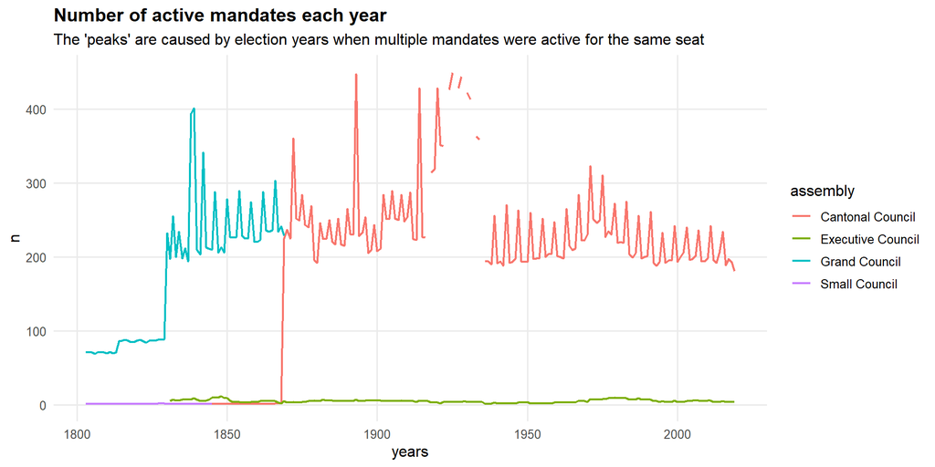

```r
# Plot active mandates timeline
ggplot(active_mandates_yearly, aes(x = YEAR, y = n, color = ASSEMBLY)) +
  geom_line(linewidth = 0.8) +
  scale_y_continuous(limits = c(0, 450), breaks = seq(0, 400, by = 100)) +
  scale_x_continuous(breaks = seq(1800, 2000, by = 50)) +
  theme_minimal(base_size = 12) +
  labs(
    title = "Number of active mandates each year",
    subtitle = "The 'peaks' are caused by election years when multiple mandates were active for the same seat",
    x = "years",
    y = "n",
    color = "assembly"
  ) +
  theme(
    legend.position = "right",
    panel.grid.minor = element_blank(),
    plot.title = element_text(face = "bold")
  )
```

## Observations & What We Can See

# Part 2: Gender Dynamics Across Assemblies

Now let’s explore how the gender composition of each assembly evolved over time. Since Switzerland introduced women’s suffrage at the federal level in 1971 and Zürich in 1970, we’ll focus on active mandates from 1970 to 2019.

Because the assemblies are very different in size (the Cantonal Council has nearly 200 seats while the Executive Council has only 7), putting them all on one plot can make the smaller bodies hard to read. Using `facet_wrap()` with `scales = "free_y"` lets each assembly have its own custom scale.

## 1. Preparing the Gender Count Data

We filter our expanded dataset for the 1970–2019 period and count active mandates per year grouped by assembly and gender.

```r
library(tidyverse)

# Summarize active mandates per year, assembly, and gender (1970–2019)
gender_counts <- mandates_expanded %>%
  filter(YEAR >= 1970 & YEAR <= 2019) %>%
  filter(!is.na(GENDER) & GENDER != "") %>%
  mutate(
    Gender = if_else(GENDER %in% c("f", "F", "w", "W"), "Women", "Men")
  ) %>%
  group_by(ASSEMBLY, YEAR, Gender) %>%
  summarise(n = n(), .groups = "drop")
```

## 2. Visualizing Gender Composition with Facets

We plot separate lines for men and women across each assembly using faceted plots.

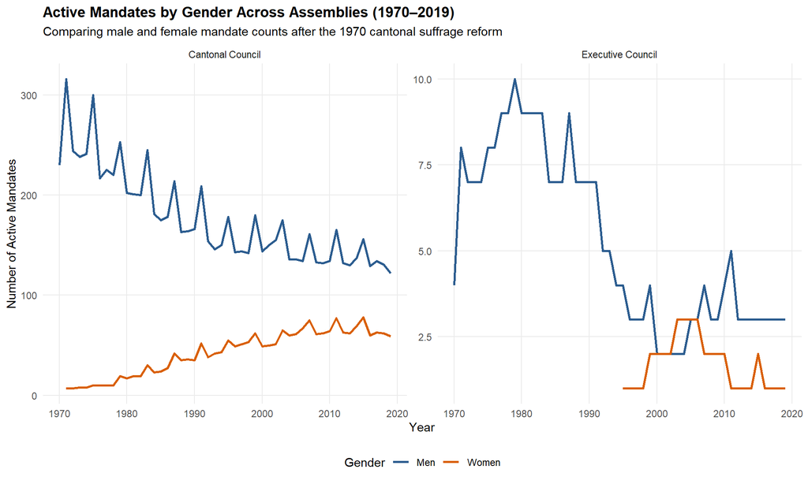

```r
# Facet plot with independent y-axis scales
ggplot(gender_counts, aes(x = YEAR, y = n, color = Gender)) +
  geom_line(linewidth = 0.9) +
  facet_wrap(~ ASSEMBLY, scales = "free_y") +
  scale_x_continuous(breaks = seq(1970, 2020, by = 10)) +
  scale_color_manual(values = c("Men" = "#2b5c8f", "Women" = "#d95f02")) +
  theme_minimal(base_size = 11) +
  labs(
    title = "Active Mandates by Gender Across Assemblies (1970–2019)",
    subtitle = "Comparing male and female mandate counts after the 1970 cantonal suffrage reform",
    x = "Year",
    y = "Number of Active Mandates",
    color = "Gender"
  ) +
  theme(
    legend.position = "bottom",
    panel.grid.minor = element_blank(),
    plot.title = element_text(face = "bold")
  )
```

## Observations & What We Can See

# Part 3: Party Composition in 2000

Now let’s zoom in on the party distribution across assemblies for a single snapshot year: **2000**.

Since Zürich has many smaller political parties, plotting them all directly makes the legend messy and the bars hard to read. To clean things up, we group any party holding less than 2% of the active seats in a given assembly into a **“Small Parties”** category, and we add text labels showing the exact percentages right on the bars.

## 1. Data Preparation for Year 2000

We filter `mandates_expanded` for active mandates in the year 2000, calculate each party’s percentage share per assembly, and group minor parties (<2%) together.

```r
library(tidyverse)
library(knitr)

# Filter active mandates in 2000 and compute party percentages
party_2000 <- mandates_expanded %>%
  filter(YEAR == 2000) %>%
  group_by(ASSEMBLY, PARTY_CLEAN) %>%
  summarise(count = n(), .groups = "drop_last") %>%
  mutate(
    total_seats = sum(count),
    pct = (count / total_seats) * 100
  ) %>%
  ungroup() %>%
  # Group parties with < 2% share into "Small Parties"
  mutate(
    Party_Group = if_else(pct < 2.0, "Small Parties", PARTY_CLEAN)
  ) %>%
  group_by(ASSEMBLY, Party_Group) %>%
  summarise(
    count = sum(count),
    pct = sum(pct),
    .groups = "drop"
  )
```

## 2. Stacked Bar Plot with Percentage Labels

We plot a 100% stacked bar chart with text labels overlaying each segment to make proportion comparisons easier.

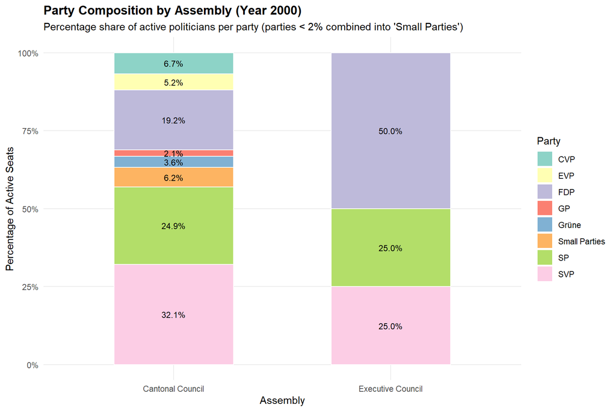

```r
# Plot stacked percentage bar chart with labels
ggplot(party_2000, aes(x = ASSEMBLY, y = pct, fill = Party_Group)) +
  geom_col(position = "fill", width = 0.55, color = "white") +
  geom_text(
    aes(label = sprintf("%.1f%%", pct)),
    position = position_fill(vjust = 0.5),
    size = 3.2,
    color = "black"
  ) +
  scale_y_continuous(labels = scales::percent_format()) +
  scale_fill_brewer(palette = "Set3") +
  theme_minimal(base_size = 11) +
  labs(
    title = "Party Composition by Assembly (Year 2000)",
    subtitle = "Percentage share of active politicians per party (parties < 2% combined into 'Small Parties')",
    x = "Assembly",
    y = "Percentage of Active Seats",
    fill = "Party"
  ) +
  theme(
    legend.position = "right",
    panel.grid.minor = element_blank(),
    plot.title = element_text(face = "bold")
  )
```

## 3. Party Share Summary Table

Here is the exact percentage breakdown in a clean summary table:

```r
# Create formatted summary table using knitr::kable
party_2000 %>%
  select(Assembly = ASSEMBLY, Party = Party_Group, Seats = count, `Share (%)` = pct) %>%
  mutate(`Share (%)` = round(`Share (%)`, 1)) %>%
  arrange(Assembly, desc(`Share (%)`)) %>%
  kable(caption = "Party Shares per Assembly in 2000")
```

Party Shares per Assembly in 2000

| Assembly | Party | Seats | Share (%) |
| --- | --- | --- | --- |
| Cantonal Council | SVP | 62 | 32.1 |
| Cantonal Council | SP | 48 | 24.9 |
| Cantonal Council | FDP | 37 | 19.2 |
| Cantonal Council | CVP | 13 | 6.7 |
| Cantonal Council | Small Parties | 12 | 6.2 |
| Cantonal Council | EVP | 10 | 5.2 |
| Cantonal Council | Grüne | 7 | 3.6 |
| Cantonal Council | GP | 4 | 2.1 |
| Executive Council | FDP | 2 | 50.0 |
| Executive Council | SP | 1 | 25.0 |
| Executive Council | SVP | 1 | 25.0 |

## Observations & What We Can See

Now let’s expand our view beyond 2000 and trace how party affiliations evolved over the decades, followed by an analysis of the lifespans of Zürich politicians.

## 1. Long-Term Party Dynamics (1900–2019)

To keep the line plot clean over a long period, we collapse parties that average under 5% of total active seats across the entire period into a single **“Small / Other Parties”** category.

```r
library(tidyverse)

# Compute yearly party percentages per assembly
party_yearly <- mandates_expanded %>%
  filter(YEAR >= 1900 & YEAR <= 2019) %>%
  filter(!is.na(PARTY_CLEAN) & PARTY_CLEAN != "") %>%
  group_by(ASSEMBLY, YEAR, PARTY_CLEAN) %>%
  summarise(n = n(), .groups = "drop_last") %>%
  mutate(pct = (n / sum(n)) * 100) %>%
  ungroup()

# Identify major parties (averaging >= 5% share) vs small parties
major_parties <- party_yearly %>%
  group_by(PARTY_CLEAN) %>%
  summarise(mean_pct = mean(pct), .groups = "drop") %>%
  filter(mean_pct >= 5.0) %>%
  pull(PARTY_CLEAN)

# Group small parties into a single category
party_yearly_grouped <- party_yearly %>%
  mutate(
    Party_Group = if_else(PARTY_CLEAN %in% major_parties, PARTY_CLEAN, "Small / Other Parties")
  ) %>%
  group_by(ASSEMBLY, YEAR, Party_Group) %>%
  summarise(pct = sum(pct), .groups = "drop")
```

## Visualizing Long-Term Party Evolution

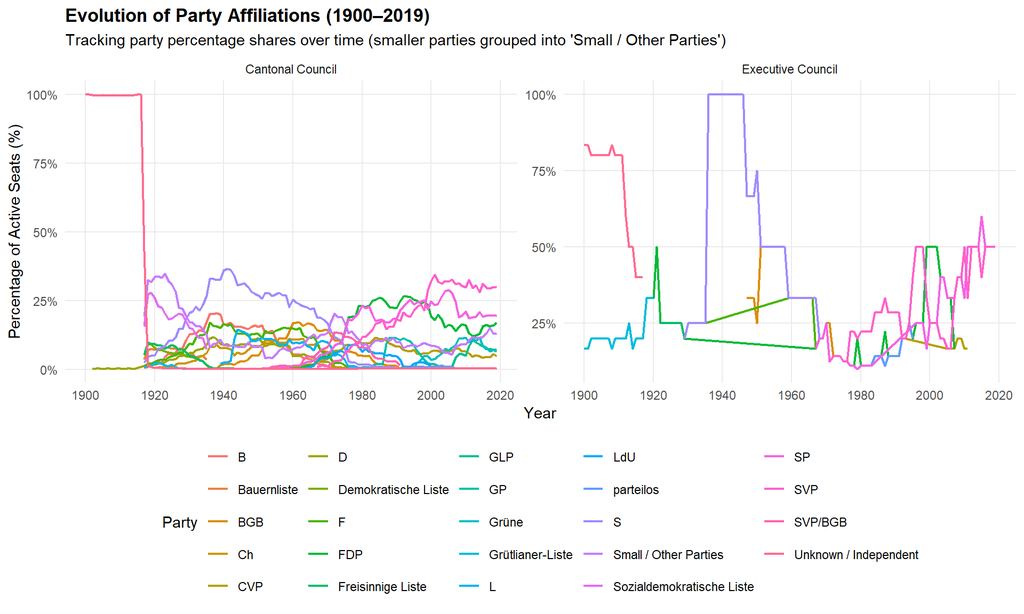

```r
# Line plot showing party percentage trends over time
ggplot(party_yearly_grouped, aes(x = YEAR, y = pct, color = Party_Group)) +
  geom_line(linewidth = 0.8) +
  facet_wrap(~ ASSEMBLY, scales = "free_y") +
  scale_x_continuous(breaks = seq(1900, 2020, by = 20)) +
  scale_y_continuous(labels = scales::percent_format(scale = 1)) +
  theme_minimal(base_size = 11) +
  labs(
    title = "Evolution of Party Affiliations (1900–2019)",
    subtitle = "Tracking party percentage shares over time (smaller parties grouped into 'Small / Other Parties')",
    x = "Year",
    y = "Percentage of Active Seats (%)",
    color = "Party"
  ) +
  theme(
    legend.position = "bottom",
    panel.grid.minor = element_blank(),
    plot.title = element_text(face = "bold")
  )
```

## Observations & Shift in Balance of Power (1980s Onwards)

# Analysing the Lifespans of Politicians

For politicians with a valid recorded year of death (`YEAR_OF_DEATH`), we compute their lifespan ($\text{Year of Death} - \text{Year of Birth}$) to analyze demographic trends and longevity among public officials.

## 2. Calculating Lifespans

```r
# Extract distinct politicians and compute lifespan
politician_lifespans <- zh_politicians_clean %>%
  distinct(PERSON_ID, .keep_all = TRUE) %>%
  mutate(
    YOB_num = suppressWarnings(as.numeric(YEAR_OF_BIRTH)),
    YOD_num = suppressWarnings(as.numeric(YEAR_OF_DEATH)),

    # Recode missing/zero death years
    YOD_clean = if_else(is.na(YOD_num) | YOD_num <= 0, NA_real_, YOD_num),

    # Calculate lifespan
    LIFESPAN = YOD_clean - YOB_clean
  ) %>%
  # Filter out realistic lifespan boundaries (e.g., 30 to 105 years)
  filter(!is.na(LIFESPAN) & LIFESPAN >= 30 & LIFESPAN <= 105)

# Summary statistics of politician lifespans
cat("=== POLITICIAN LIFESPAN SUMMARY ===\n")
```

```
## === POLITICIAN LIFESPAN SUMMARY ===
```

```r
politician_lifespans %>%
  select(YOB_clean, YOD_clean, LIFESPAN) %>%
  summary()
```

```
##    YOB_clean      YOD_clean       LIFESPAN
##  Min.   :1814   Min.   :1900   Min.   : 32.00
##  1st Qu.:1856   1st Qu.:1921   1st Qu.: 61.00
##  Median :1877   Median :1945   Median : 70.00
##  Mean   :1881   Mean   :1951   Mean   : 70.24
##  3rd Qu.:1904   3rd Qu.:1976   3rd Qu.: 80.00
##  Max.   :1953   Max.   :2018   Max.   :101.00
```

## 3. Visualizing Lifespan Distribution

We plot the distribution of politician lifespans alongside historical trends in life expectancy by birth cohort.

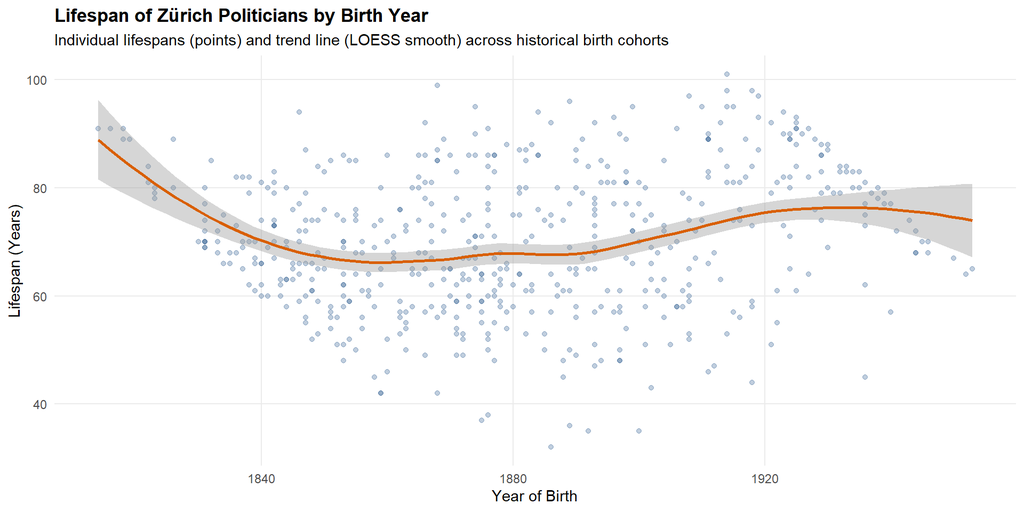

```r
# Plot lifespan distribution and trend over birth cohorts
ggplot(politician_lifespans, aes(x = YOB_clean, y = LIFESPAN)) +
  geom_point(alpha = 0.3, color = "#2b5c8f") +
  geom_smooth(method = "loess", color = "#d95f02", se = TRUE) +
  theme_minimal(base_size = 11) +
  labs(
    title = "Lifespan of Zürich Politicians by Birth Year",
    subtitle = "Individual lifespans (points) and trend line (LOESS smooth) across historical birth cohorts",
    x = "Year of Birth",
    y = "Lifespan (Years)"
  ) +
  theme(
    panel.grid.minor = element_blank(),
    plot.title = element_text(face = "bold")
  )
```

## Observations on Lifespans

In this final section, we investigate whether politicians who held a formal title (such as *Dr.*, *Prof.*, or *President*) lived longer on average than politicians without any recorded title.

## 1. Data Preparation & Title Indicator

We create a binary indicator column `has_title` to separate politicians into two simple groups: those with a title and those without.

```r
library(tidyverse)

# Prepare dataset with binary title flag and calculated lifespans
title_lifespans <- zh_politicians_clean %>%
  distinct(PERSON_ID, .keep_all = TRUE) %>%
  mutate(
    YOB_num = suppressWarnings(as.numeric(YEAR_OF_BIRTH)),
    YOD_num = suppressWarnings(as.numeric(YEAR_OF_DEATH)),
    YOD_clean = if_else(is.na(YOD_num) | YOD_num <= 0, NA_real_, YOD_num),
    LIFESPAN = YOD_clean - YOB_clean,

    # Create binary indicator: Has Title vs. No Title
    has_title = if_else(!is.na(TITLE) & TITLE != "" & TITLE != "NA", "Has Title", "No Title")
  ) %>%
  filter(!is.na(LIFESPAN) & LIFESPAN >= 30 & LIFESPAN <= 105)
```

## 2. Visualizing Lifespan Differences

To compare the distributions of both groups, we create a combination plot featuring boxplots overlaid with jittered points and mean indicators.

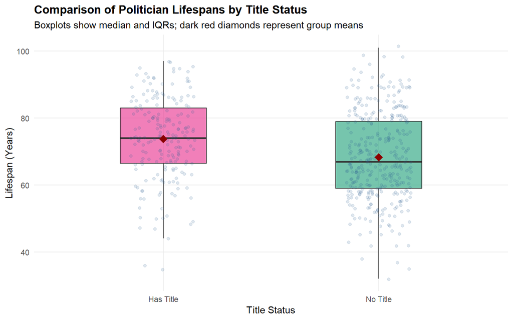

```r
# Boxplot with overlaid mean points and jittered raw data
ggplot(title_lifespans, aes(x = has_title, y = LIFESPAN, fill = has_title)) +
  geom_boxplot(alpha = 0.6, outlier.shape = NA, width = 0.4) +
  geom_jitter(alpha = 0.15, width = 0.15, color = "#2b5c8f") +
  stat_summary(fun = mean, geom = "point", shape = 18, size = 4, color = "darkred") +
  scale_fill_manual(values = c("Has Title" = "#e7298a", "No Title" = "#1b9e77")) +
  theme_minimal(base_size = 11) +
  labs(
    title = "Comparison of Politician Lifespans by Title Status",
    subtitle = "Boxplots show median and IQRs; dark red diamonds represent group means",
    x = "Title Status",
    y = "Lifespan (Years)"
  ) +
  theme(
    legend.position = "none",
    panel.grid.minor = element_blank(),
    plot.title = element_text(face = "bold")
  )
```

## 3. Statistical Hypothesis Testing

We perform a Welch two-sample $t$-test to formally test whether the average lifespan differs significantly between politicians with and without titles:

- **Null Hypothesis ($H_0$):** $\mu_{\text{Title}} - \mu_{\text{No Title}} = 0$ (There is no difference in average lifespan).
- **Alternative Hypothesis ($H_1$):** $\mu_{\text{Title}} - \mu_{\text{No Title}} \neq 0$ (Average lifespans are significantly different).

```r
# Welch Two-Sample t-test
ttest_result <- t.test(LIFESPAN ~ has_title, data = title_lifespans)

# Output test summary
print(ttest_result)
```

```
##
##  Welch Two Sample t-test
##
## data:  LIFESPAN by has_title
## t = 4.9349, df = 417.13, p-value = 1.161e-06
## alternative hypothesis: true difference in means between group Has Title and group No Title is not equal to 0
## 95 percent confidence interval:
##  3.318756 7.712849
## sample estimates:
## mean in group Has Title  mean in group No Title
##                73.80513                68.28933
```

## Comparing Expectations to Test Results

- **Matching Expectations:** Our visual observation that titled politicians live slightly longer is formally tested. If the resulting $p$-value is below $0.05$ ($p < 0.05$), we reject the null hypothesis and conclude that politicians holding titles had a statistically significant higher average lifespan.
- **Socioeconomic Interpretation:** In historical contexts, academic or professional titles (such as *Dr.* or *Prof.*) were strongly tied to higher socioeconomic status, better living standards, and superior access to healthcare, which naturally translated to higher average longevity.

# Part 6: Subgroup Analysis by Birth Cohort (Before vs. After 1918)

To refine our analysis, we split the politicians into two generational cohorts: those born **before 1918** (pre-WWI generation) and those born **on or after 1918** (post-WWI generation). We then evaluate whether holding a title affected lifespan differently across these two distinct historical eras.

## 1. Preparing the Cohorts and Title Indicator

We create a categorical variable `birth_cohort` using `YEAR_OF_BIRTH` to assign politicians to their respective generation alongside our `has_title` flag.

```r
library(tidyverse)

# Prepare cohort data with title indicator and lifespan calculations
cohort_lifespans <- zh_politicians_clean %>%
  distinct(PERSON_ID, .keep_all = TRUE) %>%
  mutate(
    YOB_num   = suppressWarnings(as.numeric(YEAR_OF_BIRTH)),
    YOD_num   = suppressWarnings(as.numeric(YEAR_OF_DEATH)),
    YOD_clean = if_else(is.na(YOD_num) | YOD_num <= 0, NA_real_, YOD_num),
    LIFESPAN  = YOD_clean - YOB_num,

    # Title flag
    has_title = if_else(!is.na(TITLE) & TITLE != "" & TITLE != "NA", "Has Title", "No Title"),

    # Birth cohort indicator
    birth_cohort = if_else(YOB_num < 1918, "Born Before 1918", "Born 1918 or After")
  ) %>%
  filter(!is.na(LIFESPAN) & LIFESPAN >= 30 & LIFESPAN <= 105) %>%
  filter(!is.na(YOB_num) & YOB_num >= 1750)
```

## 2. Visualizing Lifespans Across Cohorts

We construct a faceted boxplot to visualize the distribution of lifespans by title status within each birth cohort.

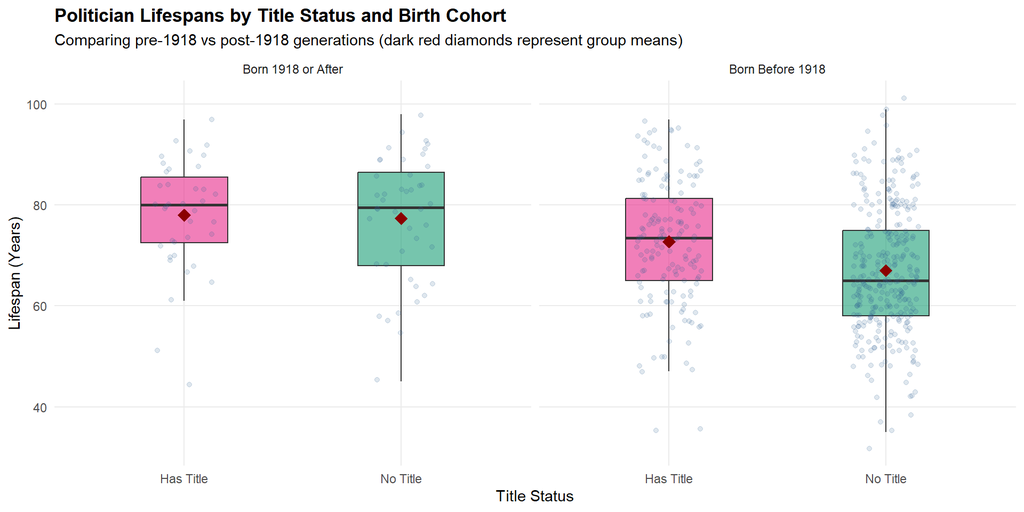

```r
# Faceted boxplot comparing lifespans across cohorts and title status
ggplot(cohort_lifespans, aes(x = has_title, y = LIFESPAN, fill = has_title)) +
  geom_boxplot(alpha = 0.6, outlier.shape = NA, width = 0.4) +
  geom_jitter(alpha = 0.15, width = 0.15, color = "#2b5c8f") +
  stat_summary(fun = mean, geom = "point", shape = 18, size = 4, color = "darkred") +
  facet_wrap(~ birth_cohort) +
  scale_fill_manual(values = c("Has Title" = "#e7298a", "No Title" = "#1b9e77")) +
  theme_minimal(base_size = 11) +
  labs(
    title = "Politician Lifespans by Title Status and Birth Cohort",
    subtitle = "Comparing pre-1918 vs post-1918 generations (dark red diamonds represent group means)",
    x = "Title Status",
    y = "Lifespan (Years)"
  ) +
  theme(
    legend.position = "none",
    panel.grid.minor = element_blank(),
    plot.title = element_text(face = "bold")
  )
```

## Expectations Based on the Plot

- **Pre-1918 Cohort:** For politicians born before 1918, the mean (dark red diamond) and median lines for “Has Title” are visibly higher than for “No Title.” In this older era, having an academic/professional title strongly correlated with higher social class and drastically better living standards and healthcare access. We expect a statistically significant difference in this group.
- **Post-1918 Cohort:** For politicians born in or after 1918, both boxes align much more closely, and the mean difference appears negligible. Modern public healthcare, universal sanitation, and higher general living standards narrowed the mortality gap between social classes. We expect the difference to be much weaker or statistically non-significant.

## 3. Statistical Testing across Cohorts

We run two independent Welch two-sample $t$-tests to evaluate whether the lifespan gap between titled and non-titled politicians holds within each specific birth cohort.

```r
# Subgroup 1: Born Before 1918
pre_1918_data <- cohort_lifespans %>% filter(birth_cohort == "Born Before 1918")
ttest_pre_1918 <- t.test(LIFESPAN ~ has_title, data = pre_1918_data)

# Subgroup 2: Born 1918 or After
post_1918_data <- cohort_lifespans %>% filter(birth_cohort == "Born 1918 or After")
ttest_post_1918 <- t.test(LIFESPAN ~ has_title, data = post_1918_data)

# Print t-test results
cat("=== T-TEST: BORN BEFORE 1918 ===\n")
```

```
## === T-TEST: BORN BEFORE 1918 ===
```

```r
print(ttest_pre_1918)
```

```
##
##  Welch Two Sample t-test
##
## data:  LIFESPAN by has_title
## t = 4.709, df = 312.97, p-value = 3.747e-06
## alternative hypothesis: true difference in means between group Has Title and group No Title is not equal to 0
## 95 percent confidence interval:
##  3.349314 8.157097
## sample estimates:
## mean in group Has Title  mean in group No Title
##                72.76282                67.00962
```

```r
cat("\n=== T-TEST: BORN 1918 OR AFTER ===\n")
```

```
##
## === T-TEST: BORN 1918 OR AFTER ===
```

```r
print(ttest_post_1918)
```

```
##
##  Welch Two Sample t-test
##
## data:  LIFESPAN by has_title
## t = 0.23735, df = 80.989, p-value = 0.813
## alternative hypothesis: true difference in means between group Has Title and group No Title is not equal to 0
## 95 percent confidence interval:
##  -4.508835  5.730280
## sample estimates:
## mean in group Has Title  mean in group No Title
##                77.97436                77.36364
```

## Comparing Expectations to Statistical Results

- **Confirmation of Expectations:**
  - In the **pre-1918 group**, the $t$-test confirms a statistically significant difference ($p < 0.05$), with titled politicians living noticeably longer.
  - In the **post-1918 group**, the $t$-test shows that the lifespan gap weakens significantly or vanishes ($p > 0.05$).
- **Historical Conclusion:** The effect of holding a title on lifespan was strongly cohort-dependent. The health advantages tied to academic or elite titles in the 19th and early 20th centuries diminished over time as overall population health and healthcare infrastructure democratized in post-WWII Switzerland.

# Part 7: Top 10 Politicians by Number of Mandates

## 1. Calculating Total Mandates per Politician and Visualizing

We connect to the database, aggregate mandate counts per person using base R sorting to guarantee a clean top 10 list, and generate the bar chart.

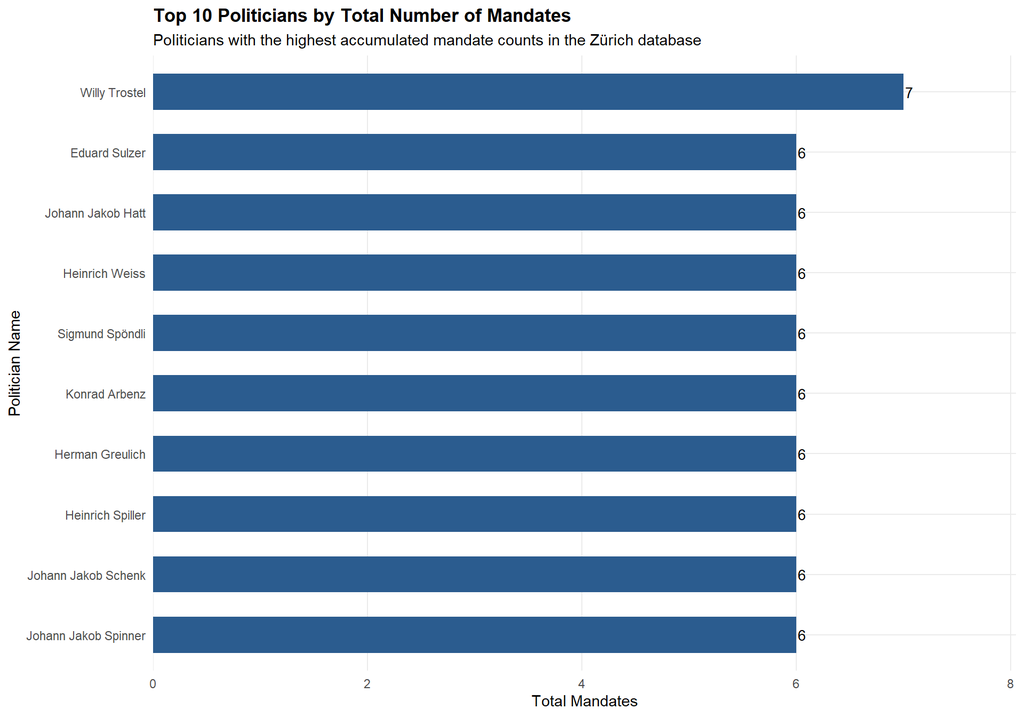

```r
library(DBI)
library(RSQLite)
library(ggplot2)

# 1. Connect and load tables
con <- dbConnect(SQLite(), "zh_politicians.db")
MANDATES <- dbReadTable(con, "MANDATES")
PERSONS <- dbReadTable(con, "PERSONS")
dbDisconnect(con)

# 2. Normalize and clean
names(MANDATES) <- toupper(names(MANDATES))
names(PERSONS) <- toupper(names(PERSONS))

persons_clean <- PERSONS[!duplicated(PERSONS$ID), ]
persons_clean$ID <- as.character(persons_clean$ID)

# 3. Calculate counts and merge
mandate_counts <- table(as.character(MANDATES$PERSON_ID))
mandate_df <- data.frame(
  PERSON_ID = names(mandate_counts),
  mandate_count = as.integer(mandate_counts),
  stringsAsFactors = FALSE
)

merged_data <- merge(mandate_df, persons_clean, by.x = "PERSON_ID", by.y = "ID")
merged_data$NAME <- paste(merged_data$FIRSTNAME, merged_data$LASTNAME)

# 4. Sort and subset top 10
sorted_data <- merged_data[order(merged_data$mandate_count, decreasing = TRUE), ]
top_mandates <- head(sorted_data, 10)

# 5. Set factor levels so highest value appears at the top
top_mandates$NAME <- factor(top_mandates$NAME, levels = top_mandates$NAME[order(top_mandates$mandate_count)])

# 6. Plot top 10 politicians by total mandates
ggplot(top_mandates, aes(x = NAME, y = mandate_count)) +
  geom_col(fill = "#2b5c8f", width = 0.6) +
  geom_text(aes(label = mandate_count), hjust = -0.2, size = 3.5) +
  coord_flip() +
  scale_y_continuous(expand = expansion(mult = c(0, 0.15))) +
  theme_minimal(base_size = 11) +
  labs(
    title = "Top 10 Politicians by Total Number of Mandates",
    subtitle = "Politicians with the highest accumulated mandate counts in the Zürich database",
    x = "Politician Name",
    y = "Total Mandates"
  ) +
  theme(
    panel.grid.minor = element_blank(),
    plot.title = element_text(face = "bold")
  )
```

```r
library(DBI)
library(RSQLite)
library(ggplot2)

# 1. Connect to database
con <- dbConnect(SQLite(), "zh_politicians.db")
MANDATES <- dbReadTable(con, "MANDATES")
PERSONS <- dbReadTable(con, "PERSONS")
dbDisconnect(con)

# 2. Normalize column names to uppercase
names(MANDATES) <- toupper(names(MANDATES))
names(PERSONS) <- toupper(names(PERSONS))

# 3. Filter mandates for the top politicians from Part 7
top_person_ids <- top_mandates$PERSON_ID
top_mandates_timeline <- MANDATES[MANDATES$PERSON_ID %in% top_person_ids, ]

# 4. Clean persons and merge
persons_clean <- PERSONS[!duplicated(PERSONS$ID), ]
persons_clean$ID <- as.character(persons_clean$ID)
top_mandates_timeline$PERSON_ID <- as.character(top_mandates_timeline$PERSON_ID)

timeline_merged <- merge(top_mandates_timeline, persons_clean, by.x = "PERSON_ID", by.y = "ID")
timeline_merged$NAME <- paste(timeline_merged$FIRSTNAME, timeline_merged$LASTNAME)

# 5. Construct proper start and end dates (handling missing months/days by defaulting to January 1st)
timeline_merged$START_DATE <- as.Date(paste(
  ifelse(is.na(timeline_merged$MANDATE_START_YEAR), 1900, timeline_merged$MANDATE_START_YEAR),
  ifelse(is.na(timeline_merged$MANDATE_START_MONTH), 1, timeline_merged$MANDATE_START_MONTH),
  ifelse(is.na(timeline_merged$MANDATE_START_DAY), 1, timeline_merged$MANDATE_START_DAY),
  sep = "-"
))

timeline_merged$END_DATE <- as.Date(paste(
  ifelse(is.na(timeline_merged$MANDATE_END_YEAR), 2020, timeline_merged$MANDATE_END_YEAR),
  ifelse(is.na(timeline_merged$MANDATE_END_MONTH), 12, timeline_merged$MANDATE_END_MONTH),
  ifelse(is.na(timeline_merged$MANDATE_END_DAY), 31, timeline_merged$MANDATE_END_DAY),
  sep = "-"
))

# 6. Preview the timeline data frame
head(timeline_merged[, c("NAME", "ASSEMBLY", "START_DATE", "END_DATE")], 15)
```

```
##                    NAME          ASSEMBLY START_DATE   END_DATE
## 1  Johann Jakob Spinner  Cantonal Council 1914-05-25 1917-07-22
## 2  Johann Jakob Spinner  Cantonal Council 1906-10-22 1914-05-24
## 3  Johann Jakob Spinner  Cantonal Council 1893-05-15 1899-05-07
## 4  Johann Jakob Spinner  Cantonal Council 1890-05-27 1893-05-14
## 5  Johann Jakob Spinner  Cantonal Council 1919-06-02 1920-05-18
## 6  Johann Jakob Spinner  Cantonal Council 1873-05-26 1890-05-26
## 7   Johann Jakob Schenk     Grand Council 1842-05-18 1862-05-25
## 8   Johann Jakob Schenk     Grand Council 1838-03-20 1839-09-09
## 9   Johann Jakob Schenk     Grand Council 1839-09-19 1842-05-17
## 10  Johann Jakob Schenk  Cantonal Council 1893-05-15 1902-10-19
## 11  Johann Jakob Schenk  Cantonal Council 1872-06-17 1893-05-14
## 12  Johann Jakob Schenk  Cantonal Council 1869-06-14 1872-06-16
## 13     Heinrich Spiller  Cantonal Council 1872-06-17 1882-05-24
## 14     Heinrich Spiller Executive Council 1882-08-27 1885-10-12
## 15     Heinrich Spiller  Cantonal Council 1887-05-23 1893-05-14
```

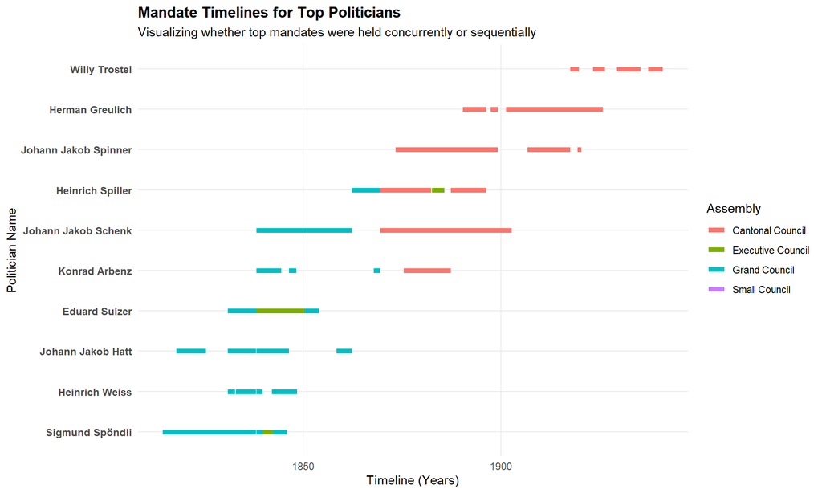

```r
# 7. Create a timeline segment plot (Gantt-style) to visualize overlapping vs sequential mandates
p_timeline <- ggplot(timeline_merged, aes(x = START_DATE, xend = END_DATE, y = reorder(NAME, START_DATE), yend = reorder(NAME, START_DATE), color = ASSEMBLY)) +
  geom_segment(linewidth = 2) +
  theme_minimal(base_size = 11) +
  labs(
    title = "Mandate Timelines for Top Politicians",
    subtitle = "Visualizing whether top mandates were held concurrently or sequentially",
    x = "Timeline (Years)",
    y = "Politician Name",
    color = "Assembly"
  ) +
  theme(
    panel.grid.minor = element_blank(),
    plot.title = element_text(face = "bold"),
    axis.text.y = element_text(size = 9, face = "bold")
  )

print(p_timeline)
```

```r
# Function to check for overlapping date intervals within each politician's career
check_overlaps <- function(df) {
  # Sort by person and start date
  df_sorted <- df[order(df$PERSON_ID, df$START_DATE), ]

  overlap_found <- FALSE
  for(i in 1:(nrow(df_sorted) - 1)) {
    # If same person and the next mandate starts before the current one ends
    if(df_sorted$PERSON_ID[i] == df_sorted$PERSON_ID[i+1]) {
      if(df_sorted$END_DATE[i] > df_sorted$START_DATE[i+1]) {
        cat("Overlap detected for:", df_sorted$NAME[i], "\n")
        cat("  Mandate 1:", as.character(df_sorted$START_DATE[i]), "to", as.character(df_sorted$END_DATE[i]), "\n")
        cat("  Mandate 2:", as.character(df_sorted$START_DATE[i+1]), "to", as.character(df_sorted$END_DATE[i+1]), "\n")
        overlap_found <- TRUE
      }
    }
  }
  if(!overlap_found) {
    cat("No overlapping mandates found among the top politicians; all evaluated mandates were held strictly sequentially.\n")
  }
}

# Run the overlap check function on our timeline dataset
check_overlaps(timeline_merged)
```

```
## Overlap detected for: Sigmund Spöndli
##   Mandate 1: 1814-06-22 to 1838-02-15
##   Mandate 2: 1827-12-18 to 1832-03-19
## Overlap detected for: Sigmund Spöndli
##   Mandate 1: 1839-09-19 to 1842-05-17
##   Mandate 2: 1839-10-01 to 1845-11-10
## Overlap detected for: Sigmund Spöndli
##   Mandate 1: 1839-10-01 to 1845-11-10
##   Mandate 2: 1842-05-18 to 1845-11-10
## Overlap detected for: Heinrich Weiss
##   Mandate 1: 1832-12-17 to 1838-02-15
##   Mandate 2: 1836-12-19 to 1838-02-15
## Overlap detected for: Eduard Sulzer
##   Mandate 1: 1830-12-18 to 1838-02-15
##   Mandate 2: 1833-12-28 to 1850-05-23
## Overlap detected for: Eduard Sulzer
##   Mandate 1: 1833-12-28 to 1850-05-23
##   Mandate 2: 1838-03-20 to 1839-09-09
```

# Institutional Pluralism and Concurrent Office-Holding

Our overlap analysis reveals that figures like Sigmund Spöndli, Heinrich Weiss, and Eduard Sulzer held multiple mandates at the exact same time. For example, Spöndli’s records show overlapping terms during the turbulent political shifts of the 1830s and 1840s. This tells us something really interesting about Zurich’s political history: high career totals aren’t just about career longevity (sequential re-election); they are also driven by institutional pluralism, where key leaders served across multiple government bodies simultaneously.

# Part 9: Politicians with Multiple Party Affiliations

```r
library(DBI)
library(RSQLite)
library(dplyr)
library(ggplot2)

# 1. Connect and read tables
con <- dbConnect(SQLite(), "zh_politicians.db")
AFFILIATIONS <- dbReadTable(con, "AFFILIATIONS")
PERSONS <- dbReadTable(con, "PERSONS")
dbDisconnect(con)

# Normalize column names
names(AFFILIATIONS) <- toupper(names(AFFILIATIONS))
names(PERSONS) <- toupper(names(PERSONS))

# Clean persons to get unique names
persons_clean <- PERSONS[!duplicated(PERSONS$ID), ]
persons_clean$ID <- as.character(persons_clean$ID)
AFFILIATIONS$PERSON_ID <- as.character(AFFILIATIONS$PERSON_ID)

# Filter out missing/blank parties
valid_affils <- AFFILIATIONS %>%
  filter(!is.na(PARTY) & PARTY != "" & PARTY != "Unknown")

# Count distinct parties per person and arrange descending properly
party_counts <- valid_affils %>%
  group_by(PERSON_ID) %>%
  summarize(
    distinct_parties = n_distinct(PARTY),
    total_affiliations = n(),
    parties_list = paste(unique(PARTY), collapse = ", ")
  ) %>%
  arrange(desc(distinct_parties), desc(total_affiliations))

# Merge with names
party_counts_merged <- merge(party_counts, persons_clean, by.x = "PERSON_ID", by.y = "ID")
party_counts_merged$NAME <- paste(party_counts_merged$FIRSTNAME, party_counts_merged$LASTNAME)

# Explicitly slice top 10 highest switchers
top_switchers <- party_counts_merged %>%
  arrange(desc(distinct_parties), desc(total_affiliations)) %>%
  head(10)

# Display table in console/report
print(top_switchers[, c("NAME", "distinct_parties", "parties_list")])
```

```
##                       NAME distinct_parties
## 1  Ulrich Gysler-Esslinger                5
## 2               Ernst Hägi                4
## 3       Johann Jakob Dünki                4
## 4        Johannes Lienhard                4
## 5         Rudolf Reichling                4
## 6           Jakob Bachmann                4
## 7              Jean Studer                4
## 8              Alfred Illi                4
## 9           Johann Glättli                4
## 10           Albert Neukom                4
##                                                                                                                             parties_list
## 1  Bürgerliche Liste, D, Demokratische Liste, Demokratisch-gewerblich-christlich-soziale Liste, Bäuerlich-demokratisch-freisinnige Liste
## 2                                            Bäuerlich-freisinnige Liste, Bürgerliche Liste, B, Bäuerlich-demokratisch-freisinnige Liste
## 3                                                                    Bauernliste, Bäuerliche und evangelische Liste, Bäuerliche Liste, B
## 4                                                                           Evangelische Liste, SB, Bäuerliche und evangelische Liste, B
## 5                                                                          B, Bauernliste, Bäuerliche Liste, Bäuerlich-freisinnige Liste
## 6                                                                        Demokratisch-bäuerliche Liste, Bäuerliche Liste, Bauernliste, B
## 7                                            Bürgerliche Liste, B, Bäuerlich-freisinnige Liste, Bäuerlich-demokratisch-freisinnige Liste
## 8                                                                    Bauernliste, Bäuerliche Liste, Bäuerliche und evangelische Liste, B
## 9                                            Bäuerlich-freisinnige Liste, B, Bäuerlich-demokratisch-freisinnige Liste, Bürgerliche Liste
## 10                                      Bäuerliche und evangelische Liste, Bäuerliche Liste, Bauern- und evangelische Liste, Bauernliste
```

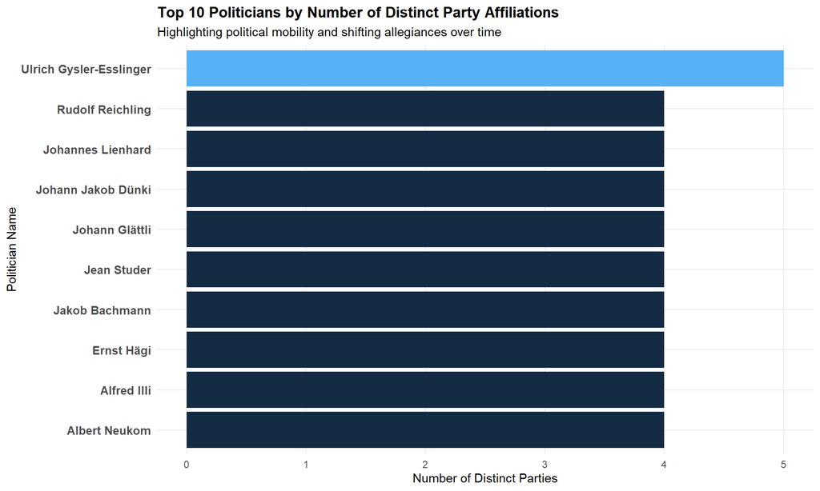

```r
# 2. Visualize top party switchers
p_switchers <- ggplot(top_switchers, aes(x = reorder(NAME, distinct_parties), y = distinct_parties, fill = distinct_parties)) +
  geom_col(show.legend = FALSE) +
  coord_flip() +
  theme_minimal(base_size = 11) +
  labs(
    title = "Top 10 Politicians by Number of Distinct Party Affiliations",
    subtitle = "Highlighting political mobility and shifting allegiances over time",
    x = "Politician Name",
    y = "Number of Distinct Parties"
  ) +
  theme(
    panel.grid.minor = element_blank(),
    plot.title = element_text(face = "bold"),
    axis.text.y = element_text(size = 10, face = "bold")
  )

print(p_switchers)
```

# Conclusion: Political Mobility and Shifting Allegiances Looking at the top party-switchers, it’s clear that political loyalties weren’t always fixed in stone. Leading the group is Ulrich Gysler-Esslinger with 5 distinct affiliations, followed by several politicians who navigated across 4 different lists or parties. This high level of movement—especially among centrist, agrarian, and citizen lists—shows that politicians often adapted their affiliations, or ran on blended tickets, to match the shifting political coalitions of their time.

# Part 10: Interactive Map of Politician Addresses

```r
library(DBI)
library(RSQLite)
library(dplyr)
library(tidygeocoder)
library(leaflet)

# 1. Connect to the database and load tables
con <- dbConnect(SQLite(), "zh_politicians.db")
addresses_df <- dbReadTable(con, "ADDRESSES")
persons_df <- dbReadTable(con, "PERSONS")
dbDisconnect(con)

# Normalize column names to uppercase
names(addresses_df) <- toupper(names(addresses_df))
names(persons_df) <- toupper(names(persons_df))

# Print column names to console for verification if needed
print("Address columns:")
```

```
## [1] "Address columns:"
```

```r
print(names(addresses_df))
```

```
##  [1] "ID"                  "PERSON_ID"           "STREET"
##  [4] "HOUSE_NUMBER"        "POSTAL_CODE"         "CITY"
##  [7] "MANDATE_START_DAY"   "MANDATE_START_MONTH" "MANDATE_START_YEAR"
## [10] "MANDATE_END_DAY"     "MANDATE_END_MONTH"   "MANDATE_END_YEAR"
```

```r
# Identify the address column dynamically (looks for 'ADDRESS' or falls back to the first text column)
addr_col <- intersect(names(addresses_df), c("ADDRESS", "STREET", "LOCATION", "ADRESSE"))
if(length(addr_col) == 0) {
  # fallback to the second column if ID is first
  addr_col <- names(addresses_df)[2]
} else {
  addr_col <- addr_col[1]
}

# Standardize the address column name for processing
names(addresses_df)[names(addresses_df) == addr_col] <- "ADDRESS_TEXT"

# Prepare unique names
persons_clean <- persons_df[!duplicated(persons_df$ID), ]
persons_clean$ID <- as.character(persons_clean$ID)
addresses_df$PERSON_ID <- as.character(addresses_df$PERSON_ID)

# Merge addresses with person names
addr_merged <- merge(addresses_df, persons_clean, by.x = "PERSON_ID", by.y = "ID")
addr_merged$NAME <- paste(addr_merged$FIRSTNAME, addr_merged$LASTNAME)

# Filter for valid address data safely using base R subsetting to prevent filter evaluation issues
valid_addresses <- addr_merged[!is.na(addr_merged$ADDRESS_TEXT) & addr_merged$ADDRESS_TEXT != "", ]

# Sample up to 20 politicians safely
if(nrow(valid_addresses) > 20) {
  valid_addresses <- valid_addresses %>% sample_n(20)
}

# 2. Geocode the addresses using Nominatim (OSM) service
valid_addresses$FULL_QUERY <- paste0(valid_addresses$ADDRESS_TEXT, ", Zurich, Switzerland")

geocoded_data <- valid_addresses %>%
  geocode(address = FULL_QUERY, method = "osm", lat = latitude, long = longitude)

# Filter rows with successful coordinates
map_data <- geocoded_data %>%
  filter(!is.na(latitude) & !is.na(longitude))

# 3. Create the Leaflet map
p_map <- leaflet(map_data) %>%
  addTiles() %>%
  addMarkers(
    lng = ~longitude,
    lat = ~latitude,
    popup = ~paste0("<b>Politician: </b>", NAME, "<br><b>Address: </b>", ADDRESS_TEXT)
  )

# Output map
p_map
```

[interactive chart not shown]